# Analiza danych federacji IHRF

**Autor:** Wojciech Derda

**Data:** 01.02.2026

**Źródło danych:** baza danych `ihrf`  
**Narzędzia:** Python (pandas, matplotlib), Jupyter Notebook

## 1. Wprowadzenie

Celem raportu jest analiza działalności federacji IHRF, obejmująca:

1. wyniki sportowe chomików i długość ich kariery ,
2. wpływ majątku właściciela na wyniki chomika,
3. popularność sportu w czasie i wyniki finansowe federacji,
4. wpływ wieku chomika na wyniki
5. wpływ płci chomika na wyniki
6. wpływ doświadczenia chomika na wyniki
7. sprawdzenie czy różne dyscypliny są tak samo konkurencyjne

## 2. Opis danych i założenia

W analizie wykorzystano tabele: `competitions`, `disciplines`, `hamsters`, `employees`, `funding_sources`, `sponsorships`, `doping_controls`.

**Uwaga metodologiczna:** baza przechowuje tylko zwycięzcę dla danych zawodów, ale przyjmujemy, że każdy chomik startuje we wszystkich zawodach w których może wziąć udział

## 3. Połączenie z bazą i wczytanie danych

W tej części nawiązujemy połączenie z bazą `ihrf` i wczytujemy tabele do środowiska `pandas`. Daty są konwertowane do typu `datetime`, aby umożliwić analizę czasową.

```
Połączono z bazą
```

## 4. Przygotowanie tabeli do analizy

Na potrzeby analizy tworzona jest jedna zbiorcza tabela `comp` poprzez połączenie:

- `competitions` (zawody),
- `disciplines` (opis konkurencji),
- `hamsters` (dane zawodników i właścicieli).

Każdy wiersz w `comp` odpowiada jednemu zwycięstwu w zawodach wraz z kontekstem dyscypliny oraz cechami chomika. Dodatkowo wyodrębniamy kolumnę `year` do analizy trendów.

|  | competition_id | discipline_id | competition_date | location | spectators_stadium | hamster_id | winner_result | name | category | description | name_hamster | birth_date | retire_date | sex | owner_id | owner_name | owner_networth | year |
| --- | --- | --- | --- | --- | --- | --- | --- | --- | --- | --- | --- | --- | --- | --- | --- | --- | --- | --- |
| 0 | 1 | 1 | 2019-03-30 | Buenos Aires | 7293 | 61 | 1.39 | Bieg na 2m | naturalna | Sprint na dystansie 2m | Chrupek3 | 2019-01-11 | 2022-01-14 | M | 39 | Kamil Nowak | 4704425.67 | 2019 |
| 1 | 2 | 4 | 2019-09-25 | Vancouver | 6293 | 21 | 5.13 | Formuła CH: Sprint | formula_ch | Wyścig na 20m | Błysk6 | 2019-06-13 | 2022-06-16 | F | 14 | Robert Wojciechowski | 6823846.22 | 2019 |
| 2 | 3 | 3 | 2019-06-23 | Sydney | 5348 | 26 | 20.36 | Bieg przez płotki | naturalna | Bieg przez płotki na dystansie 20m | Mocha | 2019-04-24 | 2021-01-16 | F | 12 | Tadeusz Olszewski | 5810091.44 | 2019 |
| 3 | 4 | 3 | 2019-10-13 | Paryż | 4700 | 61 | 9.25 | Bieg przez płotki | naturalna | Bieg przez płotki na dystansie 20m | Chrupek3 | 2019-01-11 | 2022-01-14 | M | 39 | Kamil Nowak | 4704425.67 | 2019 |
| 4 | 5 | 5 | 2019-06-20 | Kair | 3231 | 61 | 499.57 | Formuła CH: Endurance | formula_ch | Wyścig na 1km | Chrupek3 | 2019-01-11 | 2022-01-14 | M | 39 | Kamil Nowak | 4704425.67 | 2019 |

## 5. Najlepsi sportowcy w dyscyplinach

Wyznaczamy najlepszego chomika osobno dla każdej dyscypliny (`discipline_id`). Ponieważ `winner_result` to czas (mniej = lepiej), porównania wewnątrz dyscyplin opieramy o znormalizowany wynik oraz liczbę zwycięstw.

|  | discipline_id | name | category | hamster_id | name_hamster | wins | best_time | avg_time | avg_score | first_win | last_win |
| --- | --- | --- | --- | --- | --- | --- | --- | --- | --- | --- | --- |
| 10 | 1 | Bieg na 2m | naturalna | 61 | Chrupek3 | 3 | 1.39 | 2.010 | 0.624710 | 2019-03-30 | 2019-07-12 |
| 25 | 2 | Bieg na 100m | naturalna | 67 | Błysk | 2 | 24.21 | 27.790 | -0.296386 | 2022-08-26 | 2022-12-14 |
| 33 | 3 | Bieg przez płotki | naturalna | 25 | Biszkopt | 2 | 5.02 | 6.655 | 1.297460 | 2020-03-16 | 2021-11-11 |
| 61 | 4 | Formuła CH: Sprint | formula_ch | 61 | Chrupek3 | 1 | 2.03 | 2.030 | 2.063318 | 2019-03-12 | 2019-03-12 |
| 69 | 5 | Formuła CH: Endurance | formula_ch | 26 | Mocha | 2 | 196.82 | 321.465 | 0.254129 | 2019-07-12 | 2019-12-10 |

## 6. Jak długo trwa „szczyt kariery” u chomików?

„Szczyt kariery” definiujemy jako okres pomiędzy pierwszym a ostatnim zwycięstwem chomika (w analizie uwzględniamy chomiki z co najmniej dwoma zwycięstwami). Pokazujemy statystyki opisowe oraz rozkład długości szczytu kariery.

```
Liczba chomików z >=2 zwycięstwami: 19
Średni szczyt kariery: 454.9 dni
Mediana szczytu kariery: 534.0 dni
25%–75%: 228.0 – 591.5 dni
```

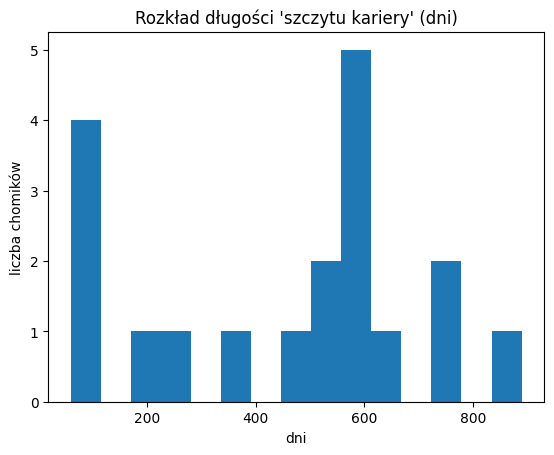

## 7. Wpływ majątku właściciela na wyniki

Sprawdzamy, czy majątek właściciela (`owner_networth`) wiąże się z lepszymi wynikami sportowymi. Stosujemy tu porównanie grup (najbogatsi 25% vs najbiedniejsi 25%) testem Manna–Whitneya.

|  | category | top25_mean_score | bottom25_mean_score | p_value | wniosek |
| --- | --- | --- | --- | --- | --- |
| 1 | naturalna | -0.239 | 0.007 | 0.4553 | NIE |
| 0 | formula_ch | 0.058 | -0.099 | 0.5962 | NIE |

## 7. Popularność sportu w czasie

Popularność oceniamy na podstawie średniej widowni stadionowej.

Na podstawie wykresu oceniamy, czy sport staje się bardziej czy mniej popularny.

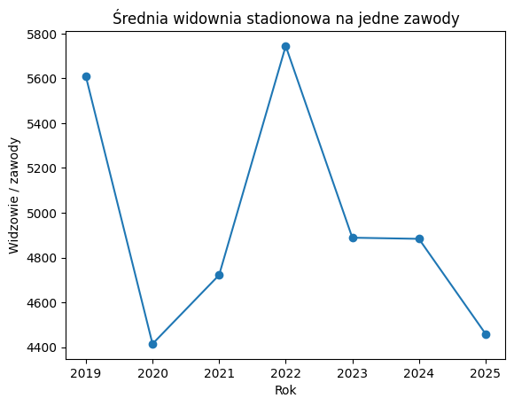

## 8. Rentowność federacji

Porównujemy przychody i wydatki w czasie:

- **przychody**: dotacje (`funding_sources`) + sponsoring (`sponsorships`),
- **wydatki**: wynagrodzenia pracowników (`employees.salary_amount × 12`).

Wynik prezentujemy jako wykres przychody vs wydatki.

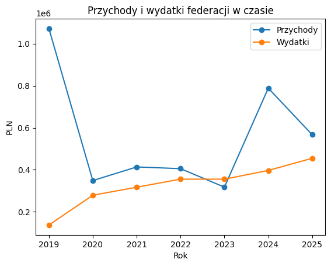

## 9. Atrakcyjność kategorii dla widzów

Porównujemy na wykresie średnią liczbę widzów dla obu kategorii.

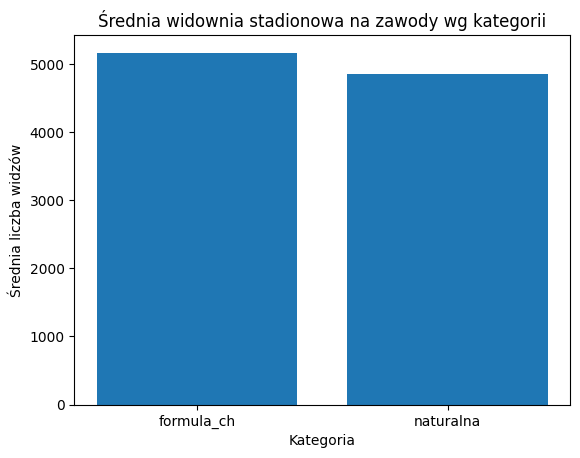

## 10. Czy wiek chomika wpływa na wyniki?

Porównujemy wiek chomika w dniach z osiągniętym przez niego wynikiem (score).

Na podstawie wykresu i testu Pearsona oceniamy czy istnieje jakaś zależność liniowa.

```
Pearson:
r = -0.097
p-value   = 0.3628
```

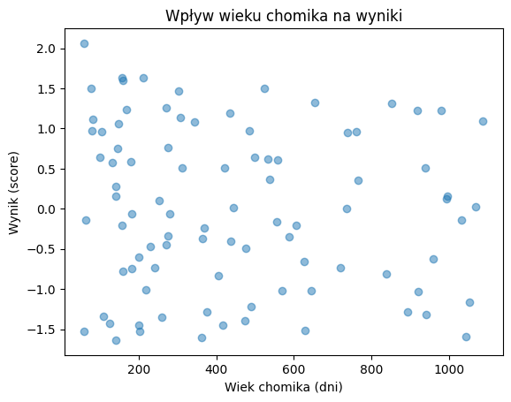

## 11. Czy płeć chomika wpływa na wyniki?

Tutaj używamy boxplotu aby łatwo sprawdzić wpływ płci na wyniki

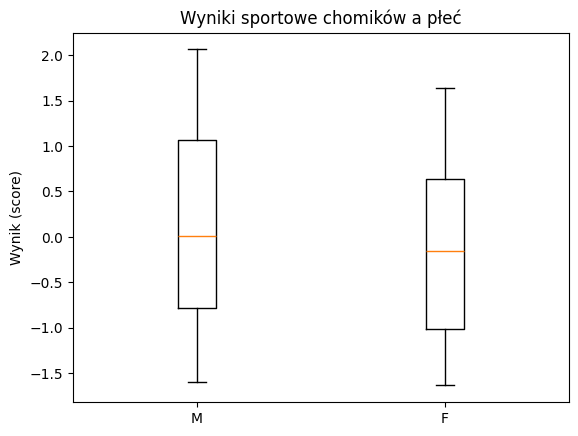

## 12. Czy długość kariery (liczba startów) wpływa na wyniki?

Tworzymy wykres, aby sprawdzić czy doświadczenie poprawia wyniki

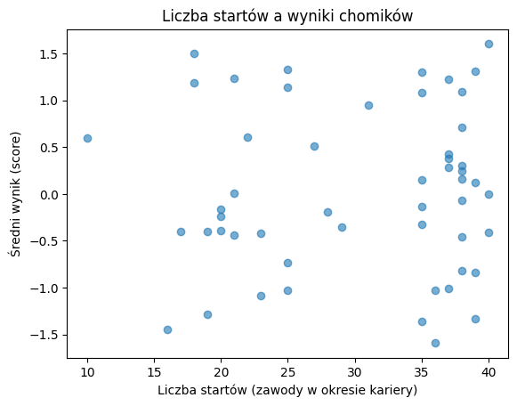

## 13. Czy dyscypliny są równie konkurencyjne?

Tutaj liczymy CV (= std/mean) dla każdej dyscypliny aby ocenić czy są one tak samo konkurencyjne

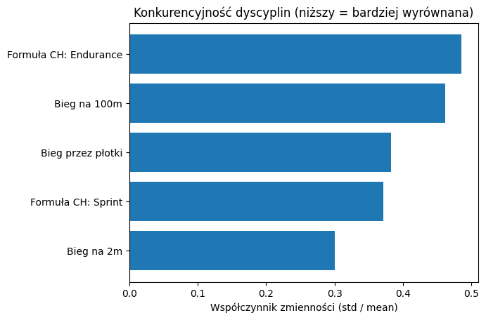

## 14. Zamykamy połączenie z bazą danych

```
Zamknięto połączenie
```